# PPtreeViz실습

212STG18_예지혜

## Huberplot

2차원 데이터의 다양한 PP 인덱스의 특성을 살펴보기 위한 plot으로, 각도를 바꿔가며 해당 인덱스의 값을 시각화한다. 점선이 중간값이므로, 그것과 비교하여 큰 값을 가지는 경우가 PP 결과 투영된 데이터이다.

- LDA 인덱스

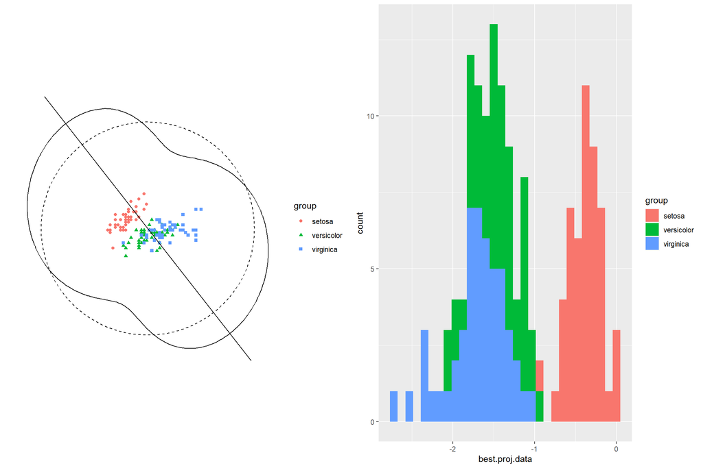

```r
library(PPtreeViz)
Huberplot(as.matrix(iris[, 1:2]), iris[, 5], PPmethod = "LDA")
```

## 논문에 있는 다섯 가지 인덱스

클래스 정보를 필요로 하는 지도학습 인덱스의 경우 origclass를 인수로 전달하는 것을 해결하지 못해 일단 origclass=iris[,5]를 내부에서 불러오는 형태로 진행

### 1. LDA

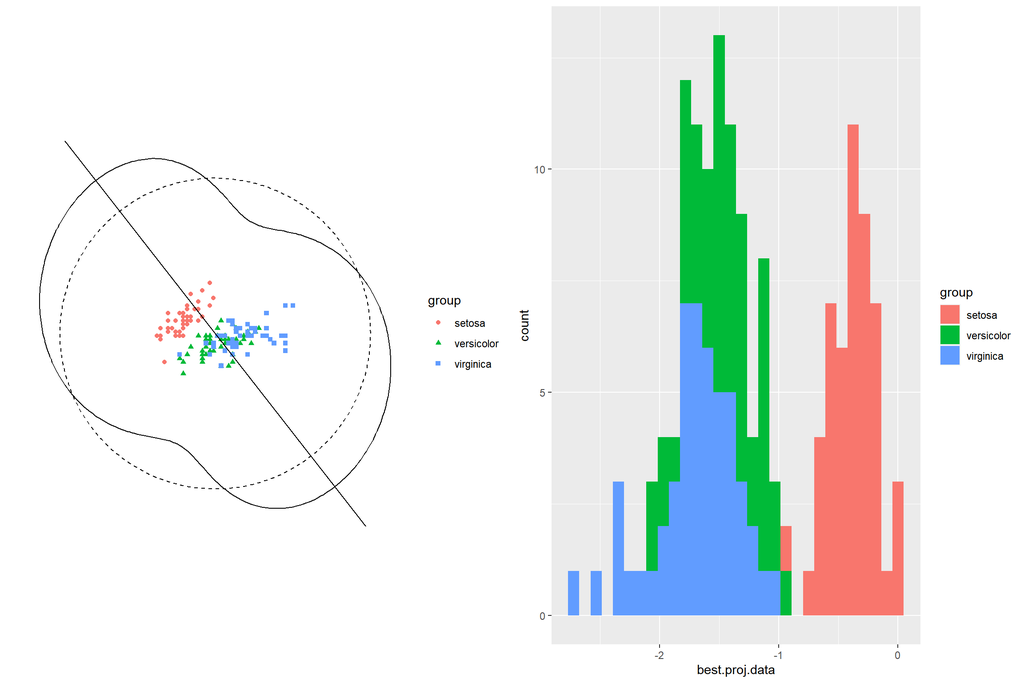

```r
LDAIndex <- function(proj.data, origC){
  B <- 0
  W <- 0
  Xbar <- mean(proj.data)

  for (a in unique(origC)){
    Xi <- proj.data[origC==a]
    ni <- length(Xi)
    Xibar <- mean(Xi)
    #print(Xibar)
    B <- B + ni * (Xibar - Xbar)^2
    W <- W + sum((Xi - Xibar)^2)
  }
  #print(1 - abs(W)/abs(W+B))
  return(1 - abs(W)/abs(W+B))
}


Huberplot(iris[, 1:2], origclass=iris[, 5], PPmethod = "UserDef",
          UserDefFtn = LDAIndex, origC=iris[,5])
```

### 2. Bhattacharya Index

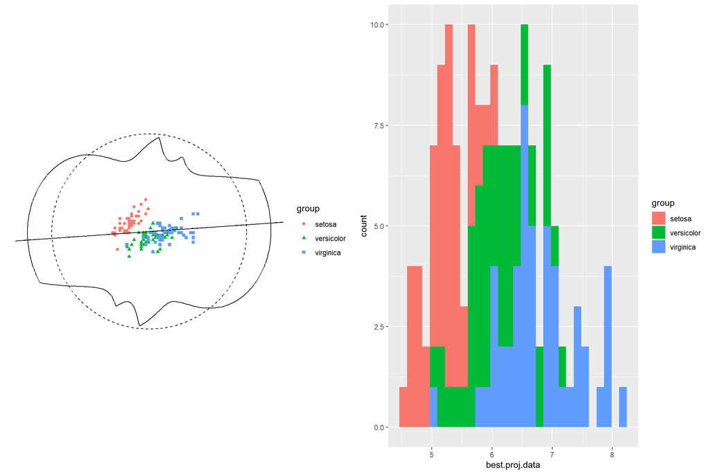

```r
BatIndex <- function(proj.data, origC){
  mu <- c()
  sigma <- c()
  result <- 100
  all_class <- unique(origC)

  # 클래스별 평균, 분산 미리 저장
  for (a in all_class){
    Xi <- proj.data[origC==a]
    mu <- c(mu, mean(Xi))
    sigma <- c(sigma, var(Xi))
  }

  # 클래스 조합 별 Bat 거리를 계산하여 저장
  for (i in 1:(length(all_class)-1)){
  # i는 처음부터 마지막 바로 전까지
    for (j in (i+1):length(all_class)){
    # j는 i 다음부터 마지막까지
      result <- min(result, 1/4*(mu[i]-mu[j])^2/(sigma[i]+sigma[j]) + 1/2*log((sigma[i]+sigma[j])/(2*sqrt(sigma[i]*sigma[j]))))
    }
  }
  #print(result)
  return(result)
}

Huberplot(iris[, 1:2], iris[, 5], PPmethod = "UserDef", UserDefFtn = BatIndex, origC=iris[,5])
```

### 3. qpc index

QPC(w) = sum(alpha X G(t(w) X (xi-xj)))

alpha는 i와 j가 같은 그룹이면 양수, 다른 그룹이면 음수인 상수

G(x) should be localized with maximum for x=0, for example Gaussian function

즉, 같은 그룹의 데이터가 가깝게 투영되면 이 인덱스 값이 커지고, 반대로 다른 그룹인데 가깝게 투영되면 이 인덱스 값이 작아진다.

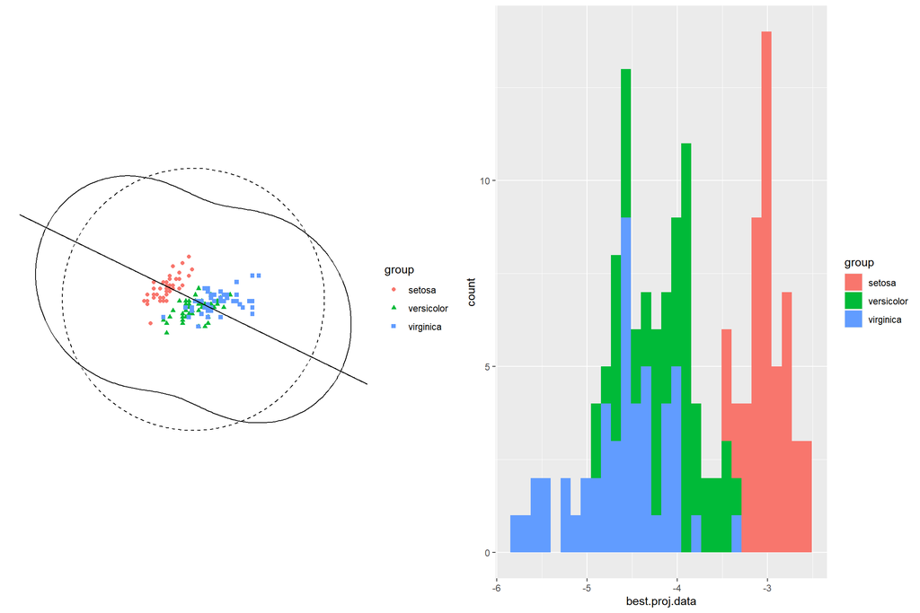

```r
QpcIndex <- function(proj.data, origC){
  result <- 0
  n <- length(proj.data)
  for (i in 1:(n-1)){
    for (j in (i+1):n){
      alpha <- ifelse(origC[i]==origC[j], 1, -1)
      result <- result + alpha*exp(-1/2*(proj.data[i]-proj.data[j])^2)
    }
  }
  #print(result)
  return(result)
}

Huberplot(iris[, 1:2], iris[, 5], PPmethod = "UserDef", UserDefFtn = QpcIndex, origC=iris[,5])
```

### 4. nca Index

일종의 cost function으로, 투영 결과, 한 점과 다른 모든 데이터와의 거리 중 이 점과 같은 클래스 간의 거리가 차지하는 비율이다. 이 인덱스가 크다는 것은, 같은 클래스에 해당하는 데이터가 가깝게 투영된다는 것을 의미한다.

[figure not shown]

```r
NcaIndex <- function(proj.data, origC){
  result <- 0
  n <- length(proj.data)

  for (i in 1:n){
    now.X <- proj.data[origC==origC[i]]
    result <- result + (sum(exp(-(proj.data[i]-now.X)^2)) - 1)/(sum(exp(-(proj.data[i]-proj.data)^2))-1)
  }

  #print(result)
  return(result)
}

Huberplot(iris[, 1:2], iris[, 5], PPmethod = "UserDef", UserDefFtn = NcaIndex, origC=iris[,5])
```

내부 함수 수정 시 plot 가능

```
## [1] 78.59708
## [1] 150 330
```

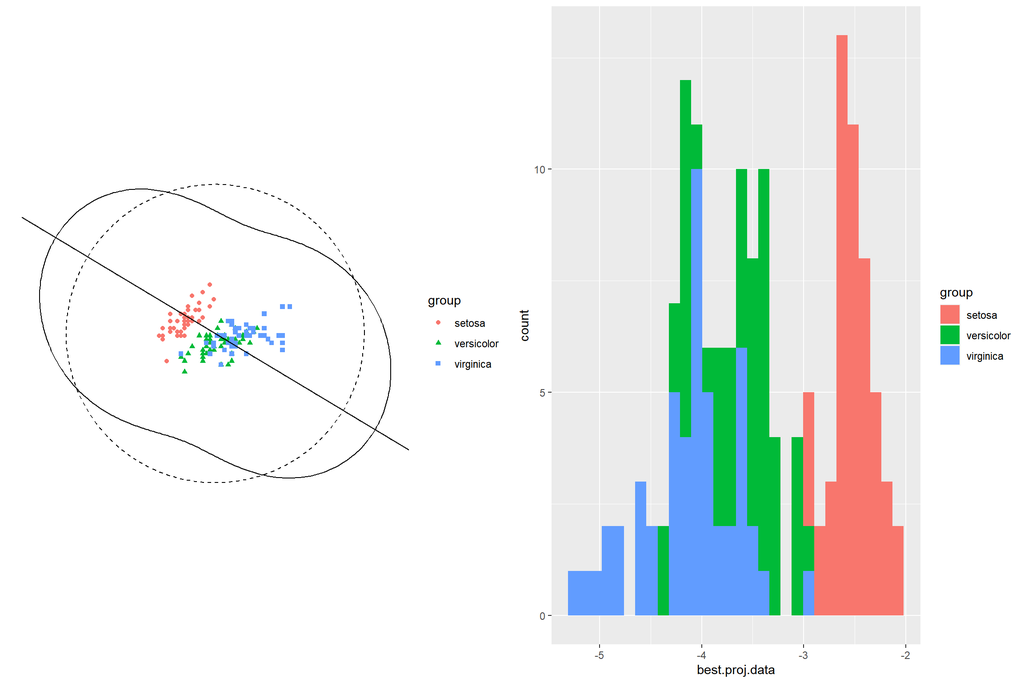

```r
huber <- function (origdata2D, origclass, PPmethod = "LDA", weight = TRUE,
                   r = 1, lambda = 0.5, opt.proj = TRUE, UserDefFtn = NULL,
                   ...)
{
  index <- NULL
  best.proj <- NULL
  best.index <- 0
  origdata2D <- as.matrix(origdata2D)
  for (i in 0:360) {
    theta <- pi/180 * i
    proj.data <- matrix(cos(theta) * origdata2D[, 1] + sin(theta) *
                          origdata2D[, 2])
    proj <- matrix(c(cos(theta), sin(theta)), ncol = 1)
    if (PPmethod == "LDA") {
      newindex <- LDAindex(origclass, origdata2D, proj = proj,
                           weight = weight)
    }
    else if (PPmethod == "PDA") {
      newindex <- PDAindex(origclass, origdata2D, proj,
                           weight = weight, lambda = lambda)
    }
    else if (PPmethod == "Lr") {
      newindex <- Lrindex(origclass, origdata2D, proj,
                          weight = weight, r = r)
    }
    else if (PPmethod == "GINI") {
      newindex <- GINIindex1D(origclass, origdata2D, proj)
    }
    else if (PPmethod == "ENTROPY") {
      newindex <- ENTROPYindex1D(origclass, origdata2D,
                                 proj)
    }
    else if (PPmethod == "UserDef") {
      newindex <- UserDefFtn(proj.data,...)
    }
    index <- c(index, newindex)
  }
  #sel.index <- which(index[1:360] > signif(max(index), 6) - 1e-06)
  sel.index <- which(index[1:360] == max(index))
  print(max(index))
  print(sel.index)
  theta.best.all <- pi/180 * (sel.index - 1)
  theta.best <- theta.best.all[1]
  proj.data.best <- matrix(cos(theta.best) * origdata2D[, 1] +
                             sin(theta.best) * origdata2D[, 2])
  index.best <- max(index)
  range <- round(max(index) - min(index), 5)
  if (range == 0) {
    PPindex <- rep(4, length(index))
  }
  else {
    PPindex <- (index - min(index))/range * 2 + 3
  }
  data.circle <- NULL
  data.index <- NULL
  for (i in 1:361) {
    theta <- pi/180 * (i - 1)
    data.index <- rbind(data.index, c(PPindex[i] * cos(theta),
                                      PPindex[i] * sin(theta)))
    data.circle <- rbind(data.circle, c(4 * cos(theta), 4 * sin(theta)))
  }
  maxdiff <- max(c(diff(range(origdata2D[, 1])), diff(range(origdata2D[,
                                                                       2]))))
  orig.scaled <- apply(origdata2D, 2, function(x) (x - mean(x))/maxdiff *  3.5)
  data.cX <- data.circle[, 1]
  data.cY <- data.circle[, 2]
  data.X <- data.index[, 1]
  data.Y <- data.index[, 2]
  plot.data <- data.frame(data.cX, data.cY, data.X, data.Y)
  x <- orig.scaled[, 1]
  y <- orig.scaled[, 2]
  group <- origclass
  point.data <- data.frame(x, y, group)
  min.X <- min(unlist(plot.data))
  max.X <- max(unlist(plot.data))
  P1 <- ggplot(data = plot.data, aes(x = data.X, y = data.Y)) +
    geom_path() + geom_path(aes(x = data.cX, y = data.cY), linetype = "dashed") + geom_point(data = point.data, aes(x = x, y = y, color = group, shape = group)) + scale_x_continuous(breaks = NULL) +
    scale_y_continuous(breaks = NULL) + xlab("") +
    ylab("") + coord_fixed() + theme_bw() + theme(panel.border = element_blank())
  if (opt.proj) {
    P1 <- P1 + geom_abline(intercept = 0, slope = sin(theta.best)/cos(theta.best))
    if (length(theta.best.all) > 1)
      for (i in 2:length(theta.best.all)) P1 <- P1 + geom_abline(intercept = 0, slope = sin(theta.best.all[i])/cos(theta.best.all[i]), linetype = "dashed")
  }
  best.proj.data <- proj.data.best
  group <- origclass
  hist.data <- data.frame(best.proj.data, group)
  P2 <- ggplot(data = hist.data, aes(x = best.proj.data, group = group)) +
    geom_histogram(aes(fill = group), position = "stack")
  gridExtra::grid.arrange(P1, P2, nrow = 1)
}

huber(iris[, 1:2], iris[, 5], PPmethod = "UserDef", UserDefFtn = NcaIndex, origC=iris[,5])
```

```r
print(signif(78.59708, 6) - 1e-06)
```

```
## [1] 78.5971
```

인덱스가 가장 큰 축을 찾지 못해서 에러가 생기는 것으로 보임.

### 5. Lpp index

Locality Preserving Projections (LPP) 방법을 기반으로 하는 비지도 학습 인덱스이다. 이 인덱스는 근처에 있는 데이터들이 투영 후에도 모이도록 유도한다.

식은 Face Recognition Using Laplacianfaces 논문의 6~7쪽에 있는 내용을 참고하여, Laplacian matrix L 대신 similarity matrix S의 식을 사용하였다.

min{sum((yi-yj)^2)*Sij}, Sij = exp(|xi-xj|^2/t), if xi is among k nearest neighbors of xj, or xj is among k nearest neighbors of xi

이를 행렬식으로 풀면 다음과 같아진다.

min{t(A)XLt(X)A}, L is the Laplacian matrix.

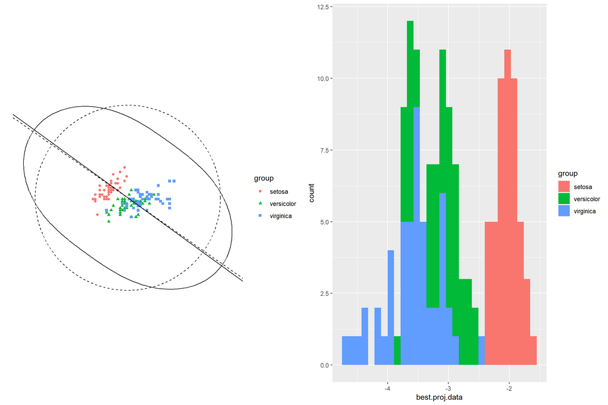

```r
LppIndex <- function(proj.data, origD, k){
  result <- 0

  for (i in 1:length(proj.data)){
    knn.ind <- order((origD[i,1]-origD[,1])^2+(origD[i,2]-origD[,2])^2)[2:(k+1)]
    for (j in knn.ind){
      result <- result + (proj.data[i]-proj.data[j])^2 * exp(sum((origD[i,]-origD[j,])^2))
    }
  }
  #print(1/result)
  return(1/result)
}

Huberplot(iris[, 1:2], iris[, 5], PPmethod = "UserDef", UserDefFtn = LppIndex, origD=iris[,1:2], k=10)
```